# try_analysis_two

Xiaotong

14/08/2020

2. Method
3. results the questions i want to answer： 1.“how good(rational) people are” (boxplot)
4. where are the mistakes (possibly) from?

3.“who is better/more rational” - numeracy, reasoning strategy, response time (run regression)

```r
### sanitise_ranks function
sanitise_ranks <- function(rank) {
  str_remove_all(rank, "_") %>%
    str_remove_all(" ")
}

### %!in% function
'%!in%' <- function(x, y) !('%in%'(x,y))


### experimental data
dat <- read.csv("ranking_data2.csv")

names(dat)[names(dat) == 'PROLIFIC_PID'] <- 'pid'

dl <- dat %>%
  select(-ends_with("order")) %>%
  pivot_longer(cols = starts_with("event_set"),
               names_to = "event", values_to = "response") %>%
  filter(str_detect(response, "\\d")) %>%
  mutate(set = str_extract(event, "\\d")) %>%
  mutate(type = str_remove(event, "event_set\\d_")) %>%
  select(-event)

dl <- dl %>%
  mutate(response = sanitise_ranks(response))


########
dl2 <- dat %>%
  select(X, pid, ends_with("order")) %>%
  pivot_longer(cols = starts_with("event_set"),
               names_to = "event", values_to = "order") %>%
  filter(!str_detect(order, "-")) %>%
  mutate(set = str_extract(event, "\\d")) %>%
  select(-event)

dl <- dl %>%
  left_join(dl2)
```

```r
########


dt_nest <- dl %>%
  group_by(X, pid, condition, set, numeracy_score, response_time, strat_1, Strat_2, order ) %>%
  nest()



### coherent formalities
coherence_all <- read.csv("rank1_strict1_strict.csv", check.names=FALSE)
coherence_all <- coherence_all[-1]
colnames(coherence_all) <- c("marginal", "conunction", "disjunction")


coherence_all <- coherence_all %>%
  mutate(marginal = sanitise_ranks(marginal),
         conjunction = sanitise_ranks(conunction),
         disjunction = sanitise_ranks(disjunction))



### write the function to calculate the coherence of the beliefs about three event sets
### （marginal event set, conjunction event set, and disjunction event set)


calc_logi_three <- function(data){
  ### browser()

  ### check if there are logical errors in rankings for marginal
  if(data[data$type == "marginal", ]$response %!in%  coherence_all$marginal){
    return(1)
  } else {
    return(0)
  }
}


### try to run the function
dt_nest <- dt_nest %>%
  mutate(logical_err = map_dbl(data, calc_logi_three))


calc_coherence_all <- function(data){
  ### browser()

  ### check if there are logical errors in rankings for marginal
  if(data[data$type == "marginal", ]$response %!in%  coherence_all$marginal){
    return(0)
  }  ### if there are logical errors, return 0

  ### get possible rankings for conjunction given the rank in margianl
  possible_ranks_conjunction <- coherence_all %>%
    filter(marginal == data[data$type == "marginal", ]$response)

  #### check if response for conjunction matches
  if(data[data$type == "conjunction", ]$response %!in% possible_ranks_conjunction$conjunction){
    return(0)
  }

  ### get possible rankings for disjunction given the ranks in marginal and conjunction
  possible_ranks_disjunction <- coherence_all %>%
    filter(marginal == data[data$type == "marginal", ]$response &
             conjunction == data[data$type == "conjunction", ]$response)

  ### check if response for disjucntion matches
  if(data[data$type == "disjunction", ]$response %in% possible_ranks_disjunction$disjunction){
    return(1)
  } else {
    return(0)
  }

}

dt_nest <- dt_nest %>%
  mutate(coherence_all = map_dbl(data, calc_coherence_all))

calc_coh_marg_conj <- function(data){
  ### browser()

  ### check if there are logical errors in rankings for marginal
  if(data[data$type == "marginal", ]$response %!in%  coherence_all$marginal){
    return(0)
  }  ### if there are logical errors, return 0

  ### get possible rankings for conjunction given the ranks in margianl
  possible_ranks_conjunction <- coherence_all %>%
    filter(marginal == data[data$type == "marginal", ]$response)

  #### check if response for conjunction matches
  if(data[data$type == "conjunction", ]$response %in% possible_ranks_conjunction$conjunction){
    return(1)
  } else{
    return(0)
  }

}

dt_nest <- dt_nest %>%
  mutate(coh_marg_conj = map_dbl(data, calc_coh_marg_conj))

calc_coh_marg_disj <- function(data){
  ### check if there are logical errors in rankings for marginal
  if(data[data$type == "marginal", ]$response %!in%  coherence_all$marginal){
    return(0)
  }  ### if there are logical errors, return 0

  ### get possible rankings for disjunction given the ranks in margianl
  possible_ranks_disjunction <- coherence_all %>%
    filter(marginal == data[data$type == "marginal", ]$response)

  #### check if response for disjunction matches
  if(data[data$type == "disjunction", ]$response %in% possible_ranks_disjunction$disjunction){
    return(1)
  } else{
    return(0)
  }
}


dt_nest <- dt_nest %>%
  mutate(coh_marg_disj = map_dbl(data, calc_coh_marg_disj))

calc_coh_conj_disj <- function(data){

  ### get possible rankings for disjunction given the ranks in conjunction
  possible_ranks_disjunction <- coherence_all %>%
    filter(conjunction == data[data$type == "conjunction", ]$response)

  ### check if response for disjunction matches
  if(data[data$type == "disjunction", ]$response %in% possible_ranks_disjunction$disjunction){
    return(1)
  }else{
    return(0)
  }
}

dt_nest <- dt_nest %>%
  mutate(coh_conj_disj = map_dbl(data, calc_coh_conj_disj))


dt_nest <- dt_nest %>%
  mutate(degree_of_coh = (coh_marg_conj + coh_marg_disj + coh_conj_disj) / 3)

dt_nest[,12:16] %>% as.tibble() %>%
  print(n=40)
```

```
## # A tibble: 376 x 5
##    coherence_all coh_marg_conj coh_marg_disj coh_conj_disj degree_of_coh
##            <dbl>         <dbl>         <dbl>         <dbl>         <dbl>
##  1             0             1             1             0         0.667
##  2             0             1             0             0         0.333
##  3             0             0             0             1         0.333
##  4             0             1             1             0         0.667
##  5             0             1             1             0         0.667
##  6             0             0             1             0         0.333
##  7             0             0             1             0         0.333
##  8             0             0             0             0         0
##  9             0             1             0             0         0.333
## 10             0             1             0             0         0.333
## 11             0             0             0             0         0
## 12             0             1             1             0         0.667
```

[output cut: 29 more lines]

```r
dt2 <- dt_nest %>%
  select(-data)
```

Quesstion 1: how good people are ?

- look at the distribution of the rate at which individual participants make logical errors under the full ranking condition

```r
dt2_full <- dt2 %>% filter(condition == "full")


dt2_full <- dt2_full %>% group_by(pid) %>%
  summarise( ave_logi = mean(logical_err),
             no_of_set = length(set))
```

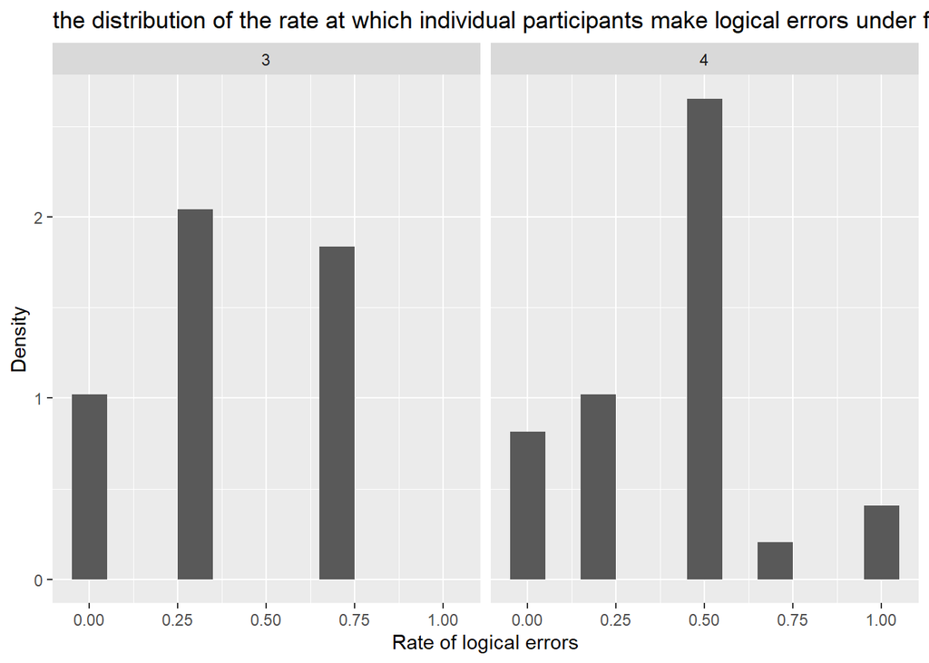

```r
ggplot(dt2_full, aes(x=ave_logi)) +
  geom_histogram(aes(y=stat(count/sum(count)/width)), binwidth = 0.1) + facet_wrap(~no_of_set) +
  ylab("Density") + xlab("Rate of logical errors") + ggtitle("the distribution of the rate at which individual participants make logical errors under full ranking condition") +
  theme(plot.title = element_text(hjust = 0.5)) + theme_set(theme_bw(base_size = 9))
```

- look at the distribution of individual’s degree of coherence under two conditions?

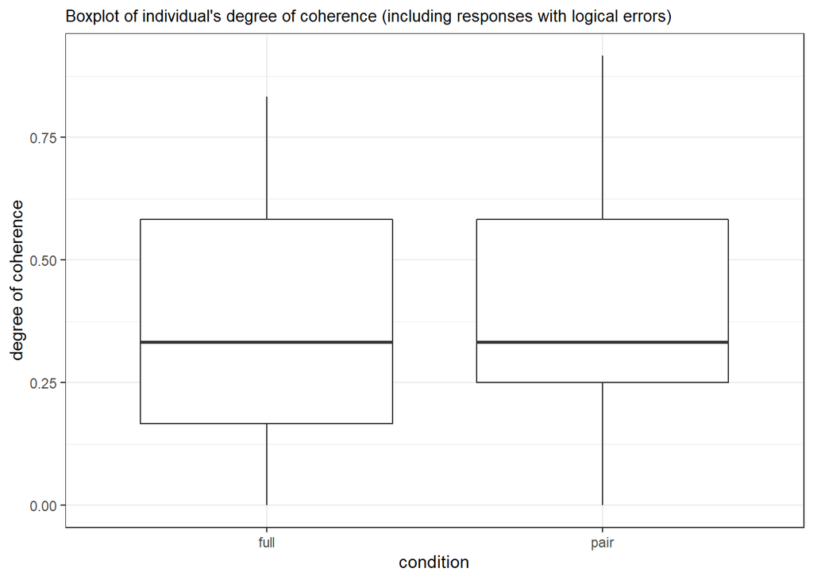

```r
dt2_coherence <- dt2 %>% group_by(pid) %>%
mutate(ave_coh = mean(degree_of_coh),
            no_of_set = length(set))


( boxplot1 <- ggplot(dt2_coherence, aes(x=condition, y=ave_coh)) +
  geom_boxplot() +
  scale_y_continuous(name = "degree of coherence") +
        ggtitle("Boxplot of individual's degree of coherence (including responses with logical errors) ")  +
        theme_bw() +
        theme(plot.title = element_text(size = 10)))
```

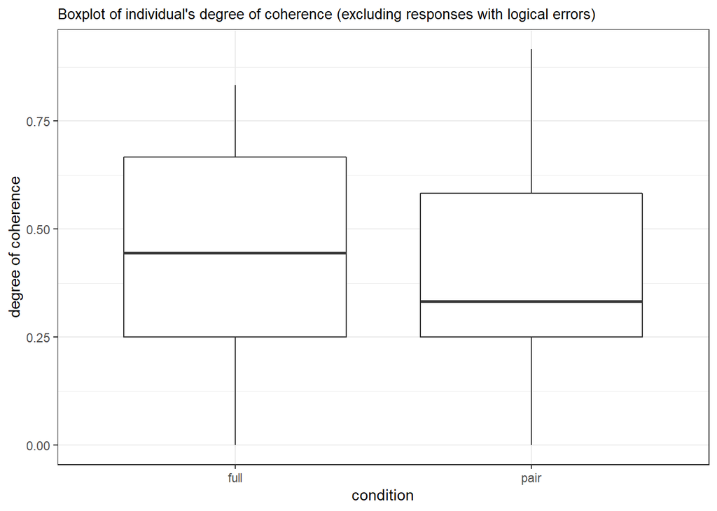

```r
dt2_coherence2 <- dt2_coherence %>%
  filter(logical_err != "1")

( boxplot2 <- ggplot(dt2_coherence2, aes(x=condition, y=ave_coh)) +
  geom_boxplot() +
  scale_y_continuous(name = "degree of coherence") +
        ggtitle("Boxplot of individual's degree of coherence (excluding responses with logical errors) ") +
        theme_bw() +
        theme(plot.title = element_text(size = 10)))
```

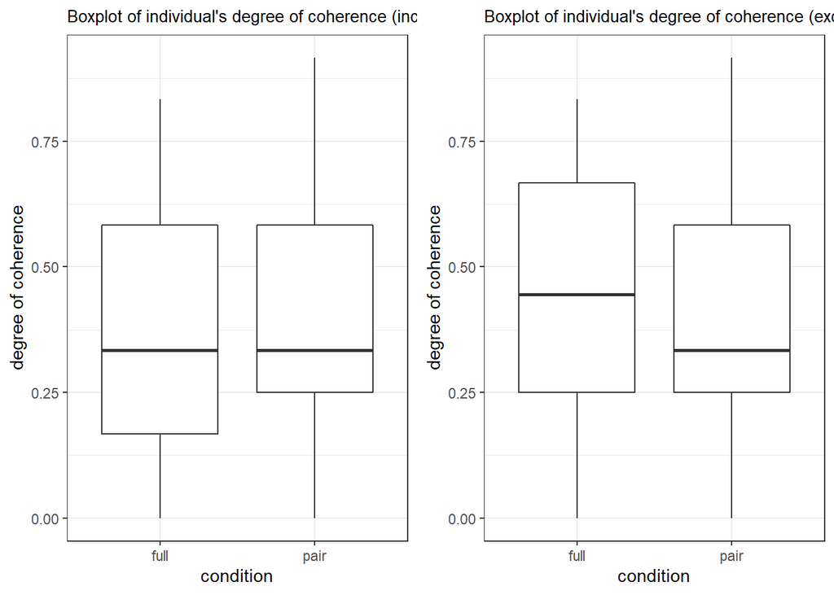

```r
plot_grid(boxplot1, boxplot2)
```

Question 2: where are the mistakes (possibly) from?

method 1: “Does the manipulation of forcing participants to do pairwise comparisons for margianl events increase the coherence between conjunction and disjunction events?” when using this method, i did not exclude any responses with logical errors

method 2: “Does the manipulation of forcing participants to do pairwise comparisons for marginal events increase the overall degree of coherence?” When using this method, i would run the ANOVA by including responses with logical errors and run the ANOVA by excluding responses with logical errors respectively.

```r
###--------- first step: add a column recording type of the event (weather event versus future related social events)

dt2$event_topic <- ifelse (dt2$set == "1" | dt2$set ==  "2" | dt2$set == "3" | dt2$set == "4", "weather",
                          ifelse(dt2$set == "5" | dt2$set ==  "6" | dt2$set == "7" | dt2$set == "8", "social",
                                 "NA"))

glimpse(dt2)
```

```
## Rows: 376
## Columns: 16
## Groups: X, pid, condition, numeracy_score, response_time, strat_1, Strat_2, set, order [376]
## $ X              <int> 1, 1, 1, 1, 2, 2, 2, 2, 3, 3, 3, 3, 4, 4, 4, 4, 5, 5, 5, 5, 6, 6, 6, 6, 7, 7, 7, 8...
## $ pid            <chr> "5e5e7e47af84e81a6ddb2a8c", "5e5e7e47af84e81a6ddb2a8c", "5e5e7e47af84e81a6ddb2a8c"...
## $ condition      <chr> "pair", "pair", "pair", "pair", "pair", "pair", "pair", "pair", "pair", "pair", "p...
## $ numeracy_score <int> 4, 4, 4, 4, 2, 2, 2, 2, 3, 3, 3, 3, 6, 6, 6, 6, 6, 6, 6, 6, 6, 6, 6, 6, 4, 4, 4, 6...
## $ response_time  <int> 746, 746, 746, 746, 928, 928, 928, 928, 1007, 1007, 1007, 1007, 1036, 1036, 1036, ...
## $ strat_1        <chr> "Imagine the likelihood of occurrence for each event on a probability scale from 0...
## $ Strat_2        <chr> "Think about more than two events at the same time and come up with rankings for t...
## $ set            <chr> "1", "4", "6", "7", "2", "3", "5", "8", "2", "3", "5", "6", "2", "4", "7", "8", "3...
## $ order          <chr> "marginal_disjunction_conjunction", "disjunction_conjunction_marginal", "conjuncti...
## $ logical_err    <dbl> 0, 0, 0, 0, 0, 0, 0, 0, 0, 0, 0, 0, 1, 0, 1, 0, 0, 1, 1, 0, 0, 0, 0, 0, 1, 0, 0, 0...
## $ coherence_all  <dbl> 0, 0, 0, 0, 0, 0, 0, 0, 0, 0, 0, 0, 0, 1, 0, 1, 1, 0, 0, 0, 0, 0, 0, 0, 0, 0, 0, 0...
## $ coh_marg_conj  <dbl> 1, 1, 0, 1, 1, 0, 0, 0, 1, 1, 0, 1, 0, 1, 0, 1, 1, 0, 0, 1, 0, 0, 0, 0, 0, 1, 1, 0...
## $ coh_marg_disj  <dbl> 1, 0, 0, 1, 1, 1, 1, 0, 0, 0, 0, 1, 0, 1, 0, 1, 1, 0, 0, 0, 0, 0, 0, 0, 0, 0, 1, 0...
## $ coh_conj_disj  <dbl> 0, 0, 1, 0, 0, 0, 0, 0, 0, 0, 0, 0, 0, 1, 1, 1, 1, 1, 0, 0, 0, 1, 1, 0, 0, 0, 0, 0...
## $ degree_of_coh  <dbl> 0.6666667, 0.3333333, 0.3333333, 0.6666667, 0.6666667, 0.3333333, 0.3333333, 0.000...
## $ event_topic    <chr> "weather", "weather", "social", "social", "weather", "weather", "social", "social"...
```

```r
###-------DV: coherence between conjunction and disjunction events
a1 <- aov_ez("pid", "coh_conj_disj", dt2, between = "condition", within = "event_topic")
```

```
## Converting to factor: condition
```

```
## Contrasts set to contr.sum for the following variables: condition
```

```r
a1
```

```
## Anova Table (Type 3 tests)
##
## Response: coh_conj_disj
##                  Effect    df  MSE        F  ges p.value
## 1             condition 1, 98 0.19     0.22 .001    .641
## 2           event_topic 1, 98 0.11 10.50 ** .038    .002
## 3 condition:event_topic 1, 98 0.11     0.78 .003    .380
## ---
## Signif. codes:  0 '***' 0.001 '**' 0.01 '*' 0.05 '+' 0.1 ' ' 1
```

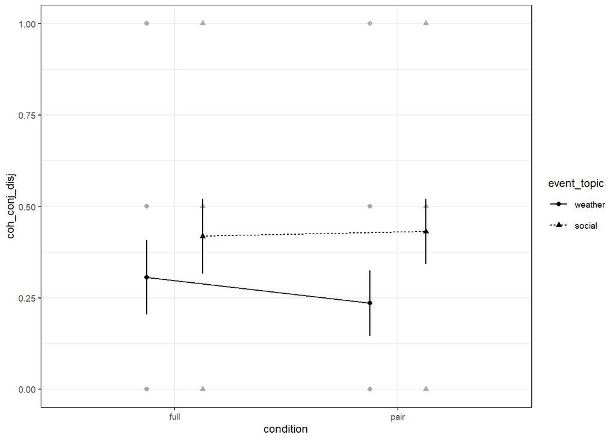

```r
afex_plot(a1, "condition", "event_topic", error = "within")
```

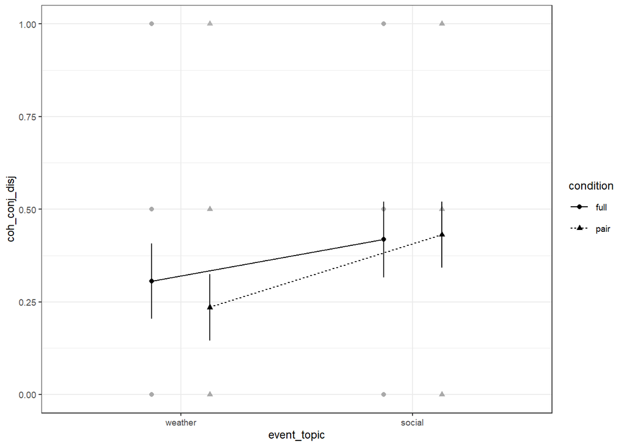

```r
afex_plot(a1, "event_topic","condition",  error = "within") ### the effect of event_topic is significant
```

```r
                                                           ### the effect of condition is not significant

##---------- DV: degree of coherence, including responses with logical errors
a2 <- aov_ez("pid", "degree_of_coh", dt2, between = "condition", within = "event_topic")
```

```
## Converting to factor: condition
```

```
## Contrasts set to contr.sum for the following variables: condition
```

```r
a2
```

```
## Anova Table (Type 3 tests)
##
## Response: degree_of_coh
##                  Effect    df  MSE       F   ges p.value
## 1             condition 1, 98 0.11    0.01 <.001    .932
## 2           event_topic 1, 98 0.07 7.91 **  .030    .006
## 3 condition:event_topic 1, 98 0.07  2.79 +  .011    .098
## ---
## Signif. codes:  0 '***' 0.001 '**' 0.01 '*' 0.05 '+' 0.1 ' ' 1
```

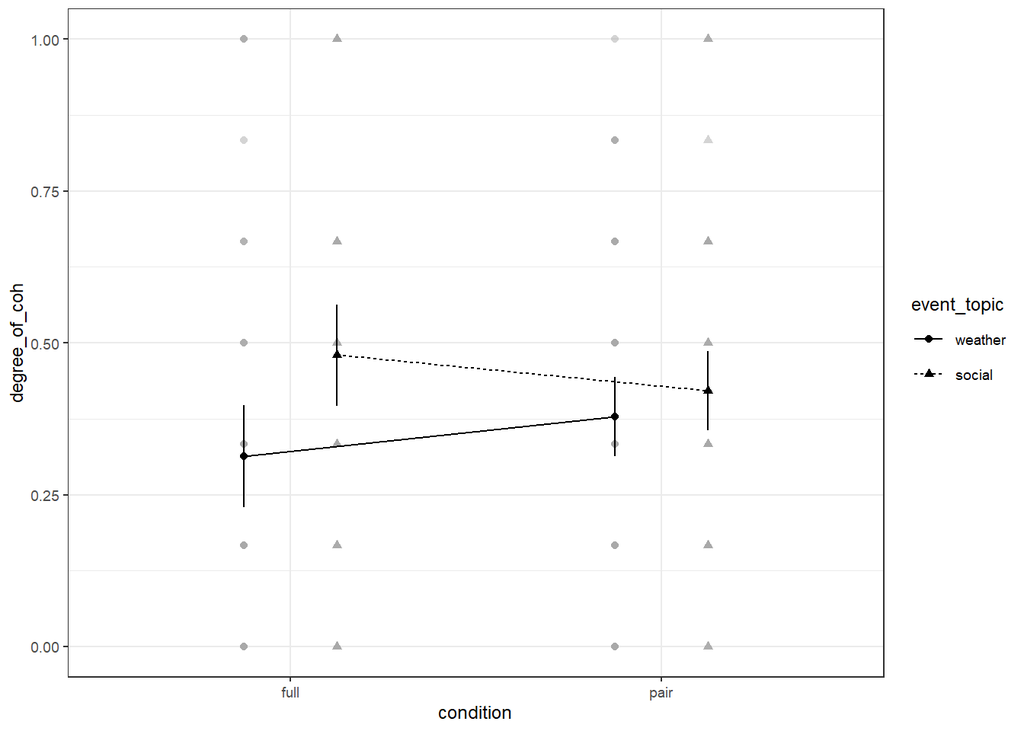

```r
afex_plot(a2, "condition", "event_topic", error = "within")
```

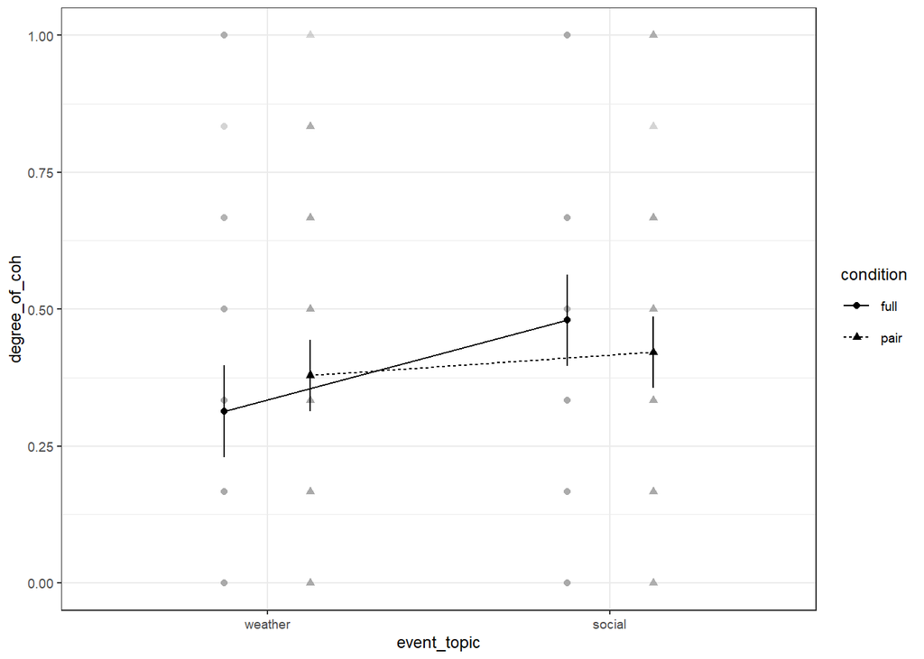

```r
afex_plot(a2, "event_topic", "condition",  error = "within") ### the effect of event_topic is significant
```

```r
                                                           ### the effect of condition is not significant


##---------- DV: degree of coherence, excluding responses with logical errors
dt2_exclude <- dt2 %>%
  filter(logical_err != "1")

a3 <- aov_ez("pid", "degree_of_coh", dt2_exclude, between = "condition", within = "event_topic")
```

```
## Converting to factor: condition
```

```
## Contrasts set to contr.sum for the following variables: condition
```